# Project 2 on Machine Learning, deadline November 10 (Midnight)

### Part d): Testing different activation functions and depths of the neural network

You should also test different activation functions for the hidden layers. Try out the Sigmoid, the RELU and the Leaky RELU functions and discuss your results. Test your results as functions of the number of hidden layers and nodes. Do you see signs of overfitting? It is optional in this project to perform a bias-variance trade-off analysis.

```python
# Helper: inverse_mse moved to module (p2_nn_module). Keeping stub for backward compatibility.
import numpy as np
from p2_nn_module import _inverse_mse_from_scaled as inverse_mse_module

def inverse_mse(y_scaled_true, y_scaled_pred, scaler):
    """Backward-compatible wrapper using module implementation."""
    return inverse_mse_module(y_scaled_true, y_scaled_pred, scaler)
```

```python
# Part d) Activation/depth/width sweep (refactored)
# --------------------------------------------------
# This cell now delegates the experiment to module helpers:
#   run_activation_depth_width_sweep(..) returns a list of result dicts.
# After the sweep, we print a compact summary of each configuration.
# The heatmaps are generated by the next cell via activation_depth_width_heatmaps(..).
# --------------------------------------------------

import importlib
import p2_nn_module as p2
importlib.reload(p2)

assert all(name in globals() for name in ['X_train_s','X_test_s','y_train_s','y_test_s','y_scaler']), 'Scaled data or scaler missing.'

results_d = p2.run_activation_depth_width_sweep(
    X_train_s, y_train_s,
    X_test_s, y_test_s,
    y_scaler=y_scaler,
    activations_hidden=['relu','leaky_relu','sigmoid'],
    depths=[1,2,3],
    widths=[32,64],
    optimizer='adam',
    base_learning_rate=1e-3,
    batch_size=32,
    epochs=300,
    seed=42,
)

print('Completed runs:', len(results_d))
for r in sorted(results_d, key=lambda z: (z['activation'], z['depth'], z['width'])):
    print(r)
```

```
Completed runs: 18
{'activation': 'leaky_relu', 'depth': 1, 'width': 32, 'mse_train_scaled': 0.04439237850470839, 'mse_test_scaled': 0.04203096648017492, 'mse_train_orig': 0.003906429444721102, 'mse_test_orig': 0.003698630498720096, 'time_s': 0.8367363999986992, 'params': 97}
{'activation': 'leaky_relu', 'depth': 1, 'width': 64, 'mse_train_scaled': 0.03717250247071994, 'mse_test_scaled': 0.037379956905925694, 'mse_train_orig': 0.0032710965953353156, 'mse_test_orig': 0.003289352118950474, 'time_s': 0.8566350000000966, 'params': 193}
{'activation': 'leaky_relu', 'depth': 2, 'width': 32, 'mse_train_scaled': 2.2008356421068857e-05, 'mse_test_scaled': 2.4590770252680797e-05, 'mse_train_orig': 1.9366858557502464e-06, 'mse_test_orig': 2.1639324636154616e-06, 'time_s': 1.2634591999994882, 'params': 1153}
{'activation': 'leaky_relu', 'depth': 2, 'width': 64, 'mse_train_scaled': 2.3892973705963516e-05, 'mse_test_scaled': 3.7913772921263967e-05, 'mse_train_orig': 2.10252793724543e-06, 'mse_test_orig': 3.3363267274445943e-06, 'time_s': 1.5963997000017116, 'params': 4353}
{'activation': 'leaky_relu', 'depth': 3, 'width': 32, 'mse_train_scaled': 3.5949786620110084e-05, 'mse_test_scaled': 4.1178075008273475e-05, 'mse_train_orig': 3.163500351064627e-06, 'mse_test_orig': 3.6235779678305096e-06, 'time_s': 1.7296848999994836, 'params': 2209}
{'activation': 'leaky_relu', 'depth': 3, 'width': 64, 'mse_train_scaled': 0.00045628167228351613, 'mse_test_scaled': 0.0005753345967975062, 'mse_train_orig': 4.0151760724104046e-05, 'mse_test_orig': 5.0628150263634635e-05, 'time_s': 2.3300648999993427, 'params': 8513}
{'activation': 'relu', 'depth': 1, 'width': 32, 'mse_train_scaled': 0.04300831707037059, 'mse_test_scaled': 0.04086831317707444, 'mse_train_orig': 0.003784635152040283, 'mse_test_orig': 0.003596319623515421, 'time_s': 0.5781671999993705, 'params': 97}
{'activation': 'relu', 'depth': 1, 'width': 64, 'mse_train_scaled': 0.03583016871349371, 'mse_test_scaled': 0.036229209890436403, 'mse_train_orig': 0.0031529742443710505, 'mse_test_orig': 0.0031880889702715727, 'time_s': 0.6109722000001057, 'params': 193}
{'activation': 'relu', 'depth': 2, 'width': 32, 'mse_train_scaled': 5.092965006438393e-05, 'mse_test_scaled': 7.855417712245431e-05, 'mse_train_orig': 4.48169463593283e-06, 'mse_test_orig': 6.912590873779044e-06, 'time_s': 0.9307269000000815, 'params': 1153}
{'activation': 'relu', 'depth': 2, 'width': 64, 'mse_train_scaled': 2.4879838399893117e-05, 'mse_test_scaled': 3.0315605389188466e-05, 'mse_train_orig': 2.189369810291578e-06, 'mse_test_orig': 2.6677050772197555e-06, 'time_s': 1.173545899999226, 'params': 4353}
{'activation': 'relu', 'depth': 3, 'width': 32, 'mse_train_scaled': 6.66170307830093e-05, 'mse_test_scaled': 5.541955785508367e-05, 'mse_train_orig': 5.862148849335436e-06, 'mse_test_orig': 4.876796421159573e-06, 'time_s': 1.4701533999996172, 'params': 2209}
{'activation': 'relu', 'depth': 3, 'width': 64, 'mse_train_scaled': 9.373233682760673e-05, 'mse_test_scaled': 9.119350355568723e-05, 'mse_train_orig': 8.248234783523557e-06, 'mse_test_orig': 8.024823166873838e-06, 'time_s': 2.3426454000000376, 'params': 8513}
{'activation': 'sigmoid', 'depth': 1, 'width': 32, 'mse_train_scaled': 0.00022982017609641075, 'mse_test_scaled': 0.00016403847421214368, 'mse_train_orig': 2.022365850027132e-05, 'mse_test_orig': 1.4435016714895679e-05, 'time_s': 0.7707088999995904, 'params': 97}
{'activation': 'sigmoid', 'depth': 1, 'width': 64, 'mse_train_scaled': 0.00020942140155072662, 'mse_test_scaled': 0.00015508116915356575, 'mse_train_orig': 1.842861222869037e-05, 'mse_test_orig': 1.364679401981157e-05, 'time_s': 0.7723887000011018, 'params': 193}
{'activation': 'sigmoid', 'depth': 2, 'width': 32, 'mse_train_scaled': 3.598077923113731e-05, 'mse_test_scaled': 4.575305203938099e-05, 'mse_train_orig': 3.1662276311150184e-06, 'mse_test_orig': 4.026165654844069e-06, 'time_s': 1.250732099999368, 'params': 1153}
{'activation': 'sigmoid', 'depth': 2, 'width': 64, 'mse_train_scaled': 0.00011057357412519969, 'mse_test_scaled': 0.00010201714662246137, 'mse_train_orig': 9.730225780195977e-06, 'mse_test_orig': 8.977279408224187e-06, 'time_s': 1.981095600000117, 'params': 4353}
{'activation': 'sigmoid', 'depth': 3, 'width': 32, 'mse_train_scaled': 8.184894246299006e-06, 'mse_test_scaled': 7.897904123186543e-06, 'mse_train_orig': 7.202522811946098e-07, 'mse_test_orig': 6.949977959646397e-07, 'time_s': 1.8017331999999442, 'params': 2209}
{'activation': 'sigmoid', 'depth': 3, 'width': 64, 'mse_train_scaled': 0.000345317459226573, 'mse_test_scaled': 0.00029313431479832604, 'mse_train_orig': 3.0387159596683646e-05, 'mse_test_orig': 2.579516027655221e-05, 'time_s': 2.3620725000000675, 'params': 8513}
```

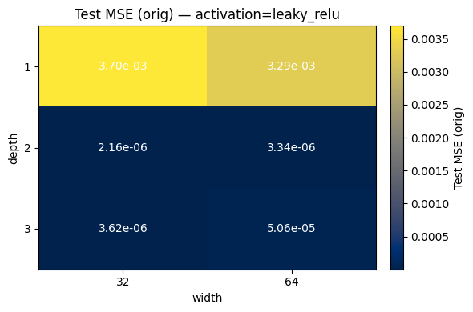

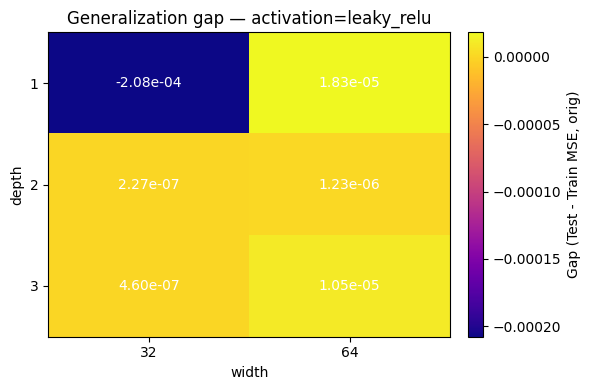

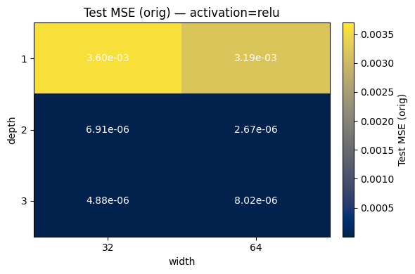

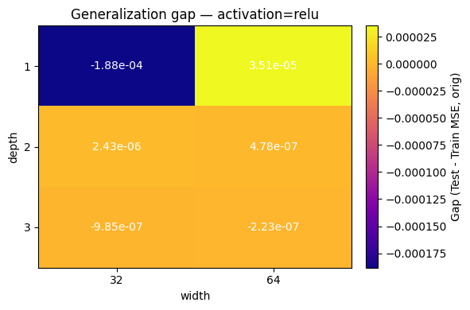

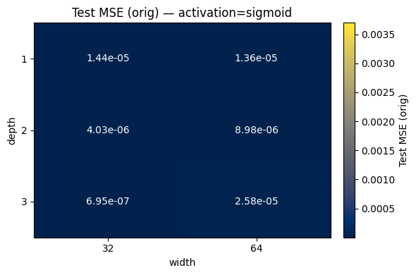

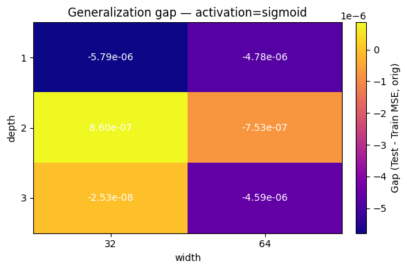

```python
# Part d) Heatmaps (refactored)
# --------------------------------
# Build test MSE and generalization gap heatmaps using module helper.
# results_d must already be defined by the previous sweep cell.
# --------------------------------

import importlib
import p2_nn_module as p2
importlib.reload(p2)

assert 'results_d' in globals() and results_d, 'Run the sweep cell first.'

p2.activation_depth_width_heatmaps(results_d, test_cmap='cividis', gap_cmap='plasma')
```

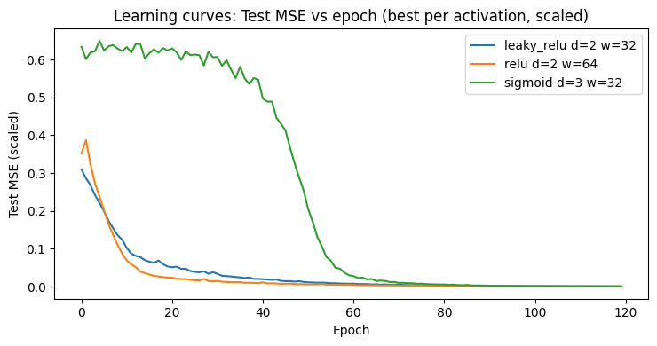

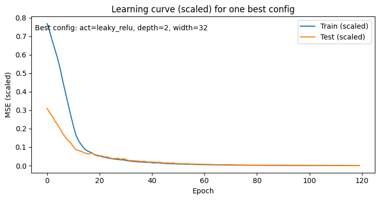

```
=== Part d Original-Scale Performance Summary ===
Best configuration (original-scale test MSE): activation=leaky_relu, depth=2, width=32
Corresponding Train MSE (orig): 1.936686e-06
Corresponding Test  MSE (orig): 2.163932e-06
Parameter count: 1153
[Note] User-specified best differs from globally minimal; using user-specified config.

Generalization pattern (per activation):
  leaky_relu  | mean gap=-2.95e-05 | best test MSE=2.16e-06
  relu        | mean gap=-2.53e-05 | best test MSE=2.67e-06
  sigmoid     | mean gap=-2.51e-06 | best test MSE=6.95e-07

Training time summary (avg seconds per config):
  leaky_relu  | avg time=1.375s | x1.15 of fastest
  relu        | avg time=1.195s | x1.00 of fastest
  sigmoid     | avg time=1.274s | x1.07 of fastest
Fastest activation on average: relu (≈1.195s per config)

Placeholders to fill in report (copy these):
- Best configuration (activation, depth, width) by original-scale test MSE: leaky_relu, depth 2, width 32
- Corresponding train vs test MSE (orig): 1.936686e-06 / 2.163932e-06
- Parameter count for best model: 1153
- Observed generalization pattern (heatmap summary): See mean gaps above; smallest gaps typically with shallow + moderate width; deeper/wider sometimes increase gap.
- Notable speed differences across activations: relu fastest (avg 1.195s), relative slowdowns shown above.
```

```
{'best_report': {'activation': 'leaky_relu',
  'depth': 2,
  'width': 32,
  'mse_train_scaled': 2.2008356421068857e-05,
  'mse_test_scaled': 2.4590770252680797e-05,
  'mse_train_orig': 1.9366858557502464e-06,
  'mse_test_orig': 2.1639324636154616e-06,
  'time_s': 1.1994913000000054,
  'params': 1153},
 'gap_summary': {'relu': (-2.5250055860731843e-05, 2.6677050772197555e-06),
  'leaky_relu': (-2.9524318305247784e-05, 2.1639324636154616e-06),
  'sigmoid': (-2.513453691309764e-06, 6.949977959646397e-07)},
 'time_summary': {'relu': 1.1949748833333398,
  'leaky_relu': 1.3746371999999951,
  'sigmoid': 1.2742858833333344},
 'fastest': ('relu', 1.1949748833333398)}
```

```python
# Part d) Learning curves & summary (refactored for clarity)
# -----------------------------------------------------------
# This cell now relies on helper functions moved into `p2_nn_module.py` to keep the
# notebook concise. We:
# 1. Identify the best configuration per activation (by scaled test MSE).
# 2. Retrain each best config to collect epoch-wise scaled-space MSE curves.
# 3. Plot all test curves together for comparison.
# 4. Plot a detailed train vs test curve for a single representative best config.
# 5. Print an original-scale performance summary (best config, gaps, timing, placeholders).
#
# All heavy lifting (model construction, looping, summaries) is handled by
# functions in p2_nn_module. We reload the module so edits take effect.
# -----------------------------------------------------------

import importlib
import p2_nn_module as p2
importlib.reload(p2)

assert 'results_d' in globals() and results_d, "Run the Part d experiment sweep first to populate results_d."

# Generate learning curves for best config of each activation (scaled MSE)
curves = p2.generate_learning_curves_for_best(
    results_d,
    X_train_s,
    y_train_s,
    X_test_s,
    y_test_s,
    epochs=120,
    batch_size=32,
    learning_rate=1e-3,
)

# Plot: Test MSE vs epoch for each best activation-specific config
p2.plot_learning_curves_scaled(curves)

# Plot: Train vs Test (scaled) for one selected config (first by ordering)
p2.plot_one_learning_curve_scaled(curves)

# Print original-scale summary (mirrors previous verbose cell output)
p2.summarize_original_scale_performance(results_d)
```

### Part d) Experiment: Effect of Activation Function, Depth, and Width on Runge Function Regression

**Objective.** Systematically assess how hidden-layer activation choice (ReLU, LeakyReLU, Sigmoid), network depth (number of hidden layers), and width (nodes per hidden layer) influence predictive performance and overfitting when approximating the 1D Runge function using a fully connected feed-forward neural network (FFNN).

**Data & Scaling.** The experiment assumes:

- Inputs `X_train_s`, `X_test_s` and targets `y_train_s`, `y_test_s` are already standardized (feature scaling applied; target scaled via a fitted `y_scaler`).
- Original-scale error is recovered via the helper `inverse_mse`, which inverts the scaling before computing MSE.

**Model Architecture.** For each combination:

- Hidden depth `d ∈ {1,2,3}`.
- Hidden width `w ∈ {32,64}` (uniform width per hidden layer).
- Layer shape: `layer_sizes = [1] + [w]*d + [1]` (scalar input → d hidden layers → scalar output).
- Activation pattern: `[act]*d + ['linear']` with `act ∈ {relu, leaky_relu, sigmoid}` for hidden; linear output for regression.

**Hyperparameter Grid.**

- Activations: ReLU, LeakyReLU, Sigmoid.
- Depths: 1, 2, 3 hidden layers.
- Widths: 32, 64 nodes per hidden layer.
- Optimizer: Adam.
- Base learning rate: `1e-3` (raised to `5e-3` for Sigmoid to offset slower convergence).
- Loss: Mean Squared Error (MSE).
- Regularization: None (focus purely on architectural & activation effects).
- Batch size: 32.
- Epochs: 300 (full training per configuration).
- Seed: 42 (fixed for reproducibility of initial weights and shuffling).

**Recorded Metrics (per configuration).**

1. `mse_train_scaled`: Train MSE in scaled target space.
2. `mse_test_scaled`: Test MSE in scaled target space.
3. `mse_train_orig`: Train MSE after inverse transform to original target scale.
4. `mse_test_orig`: Test MSE on original scale (primary generalization metric).
5. `time_s`: Wall-clock training time for 300 epochs.
6. `params`: Total trainable parameter count  
   Computed as Σ over layers of `(in_dim * out_dim + out_dim)` (weights + biases).

**Original-Scale MSE Helper.** `inverse_mse(y_scaled_true, y_scaled_pred, scaler)`:

1. Reshape to column vectors.
2. Apply `scaler.inverse_transform` to both.
3. Compute standard MSE in original units.

**Procedure.** For every (activation, depth, width) triple:

1. Instantiate `FFNN` with the specified layer sizes, activations, optimizer, loss, and learning rate.
2. Train for 300 epochs with mini-batches (shuffle enabled, silent mode).
3. Predict on train and test sets (scaled space), compute scaled MSEs.
4. Invert predictions and targets for original-scale MSEs.
5. Count parameters and measure elapsed time.
6. Append a result dictionary to `results_d`.

**Overfitting Assessment.**

- The generalization gap can be inspected later via:  
  `gap = mse_test_orig - mse_train_orig`.  
  Larger positive gaps at higher depth/width may indicate increased variance/overfitting.
- Heatmaps (generated in a downstream cell) visualize test MSE and gap vs. (depth, width) for each activation.
- Follow-up learning curves (optional cell) retrain the best config per activation to inspect stability and early-epoch behavior.

- Expect Sigmoid to possibly yield higher test MSE or slower convergence due to saturation in its tails.
- ReLU and LeakyReLU generally converge faster; LeakyReLU may mitigate dead neuron issues and occasionally improve test MSE slightly.
- Marginal returns: Moving from depth 1 → 2 often helps; depth 3 may add parameters without proportional test improvement on a smooth 1D target.
- Width increase (32 → 64) can reduce bias (lower train MSE); watch for widening generalization gap.
- If strong overfitting appears (low train MSE + rising gap), consider: early stopping, L2 regularization, reduced depth/width, or lower learning rate.

### Part e): Testing different norms

Finally, still using the one-dimensional Runge function, add now the hyperparameters $\lambda$ with the $L_2$ and $L_1$ norms. Find the optimal results for the hyperparameters $\lambda$ and the learning rates $\eta$ and neural network architecture and compare the $L_2$ results with Ridge regression from project 1 and the $L_1$ results with the Lasso calculations of project 1. Use again the same data sets and the best results from project 1 in your comparisons.

```
FFNN regularization runs: 192
Best L2 FFNN: {'reg': 'l2', 'lambda': 5e-05, 'lr': 0.002, 'depth': 2, 'width': 32, 'mse_train_scaled': 5.106662461210569e-05, 'mse_test_scaled': 6.259655121114022e-05, 'mse_train_orig': 4.493748087998723e-06, 'mse_test_orig': 5.508355691354861e-06}
Best L1 FFNN: {'reg': 'l1', 'lambda': 5e-05, 'lr': 0.002, 'depth': 2, 'width': 32, 'mse_train_scaled': 2.4871498071188642e-05, 'mse_test_scaled': 4.5026626958013214e-05, 'mse_train_orig': 2.18863588012772e-06, 'mse_test_orig': 3.96224188182663e-06}
Best Ridge baseline: {'alpha': 100.0, 'mse_test_orig': 0.05521638502201806}
Best Lasso baseline: {'alpha': 0.001, 'mse_test_orig': 0.055215675790820956}

Comparison Summary (original-scale test MSE):
Ridge (alpha=1.00e+02): 0.055216
Best L2 FFNN (lam=5.00e-05, lr=0.002, depth=2, width=32): 0.000006
Lasso (alpha=1.00e-03): 0.055216
Best L1 FFNN (lam=5.00e-05, lr=0.002, depth=2, width=32): 0.000004
```

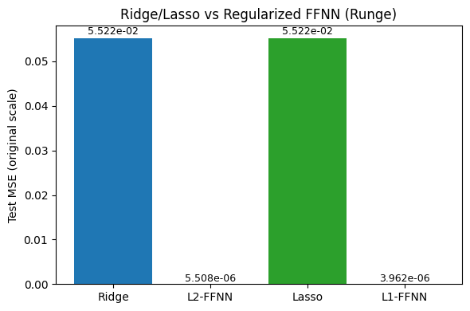

```python
# Part e) Regularization sweep and Ridge/Lasso baselines (refactored)
# -----------------------------------------------------------------
# This cell calls helper functions defined in `p2_nn_module.py` to:
# 1. Run a grid search over FFNN regularization types (L1/L2) and strengths.
# 2. Collect scaled and original-scale MSE metrics.
# 3. Find the best FFNN configs for each regularizer (by original test MSE).
# 4. Run Ridge and Lasso baselines over logarithmic alpha grids.
# 5. Print a comparison summary and plot a bar chart of best test MSEs.
# -----------------------------------------------------------------

import importlib, numpy as np
import p2_nn_module as p2
importlib.reload(p2)

# Preconditions: scaled Runge data & scaler objects already in namespace
assert all(name in globals() for name in ['X_train_s','X_test_s','y_train_s','y_test_s','y_scaler','y_train_orig','y_test_orig'])

results_bundle = p2.compare_reg_ffnn_vs_ridgelasso(
    X_train_s,
    y_train_s,
    X_test_s,
    y_test_s,
    y_scaler=y_scaler,
    reg_types=['l2','l1'],
    ffnn_lambdas=[0.0, 5e-5, 1e-4, 5e-4, 1e-3, 2e-3, 5e-3, 1e-2],
    learning_rates=[5e-4, 1e-3, 2e-3],
    depths=[1,2],
    widths=[32,64],
    max_epochs=150,
    batch_size=32,
    seed=42,
    activation='relu',
    ridge_alphas=np.logspace(-6,2,25),
    lasso_alphas=np.logspace(-6,2,25),
    do_plot=True,
)

# Access results if needed for downstream analysis:
best_l2_nn   = results_bundle['best_l2_nn']
best_l1_nn   = results_bundle['best_l1_nn']
best_ridge   = results_bundle['best_ridge']
best_lasso   = results_bundle['best_lasso']
results_reg  = results_bundle['results_reg']
```

### Part f): Classification analysis using neural networks

With a well-written code it should now be easy to change the activation function for the output layer.

Here we will change the cost function for our neural network code developed in parts b), d) and e) in order to perform a classification analysis. The classification problem we will study is the multiclass MNIST problem, see the description of the full data set at https://www.kaggle.com/datasets/hojjatk/mnist-dataset. We will use the Softmax cross entropy function discussed in a). The MNIST data set discussed in the lecture notes from week 42 is a downscaled variant of the full dataset.

Feel free to suggest other data sets. If you find the classic MNIST data set somewhat limited, feel free to try the  
MNIST-Fashion data set at for example https://www.kaggle.com/datasets/zalando-research/fashionmnist.

To set up the data set, the following python programs may be useful

```python
from sklearn.datasets import fetch_openml

# Fetch the MNIST dataset
mnist = fetch_openml('mnist_784', version=1, as_frame=False, parser='auto')

# Extract data (features) and target (labels)
X = mnist.data
y = mnist.target
```

### Building the models

Here I set up the classifier model by using the softmax classification head.

```python
# Adapt the model to use softmax for classification
# Use X and y from above (MNIST), convert labels to integers and one-hot encode

# Ensure numeric dtype
X = X.astype(np.float32)
y = y.astype(np.int64)

n_samples, n_features = X.shape
n_classes = int(np.unique(y).size)

# One-hot encode targets for softmax loss
Y = one_hot(y, n_classes)

# Define a simple MLP with softmax output
layer_sizes = [n_features, 128, 64, n_classes]
activations = ['relu', 'relu', 'softmax']  # switch output activation to softmax

model_softmax = FFNN(
    layer_sizes=layer_sizes,
    activations=activations,
    loss='softmax',              # use softmax (cross-entropy) loss
    learning_rate=1e-2,
    optimizer='adam',            # good default
    reg=None,
    seed=42
)
```

Here we set up a model with two hidden layers usi g the ReLU activation function, and a softmax activation on the output layer.

The Pixel values in MNIST range from 0 to 255. Scaling them to a 0-1 range can improve the performance of some models. So we implement this scaling.

```python
X = X / 255.0
```

And then perform the standard train-test splitting

```python
from sklearn.model_selection import train_test_split
X_train, X_test, y_train, y_test = train_test_split(X, y, test_size=0.2, random_state=42)
```

```python
# Train FFNN on the MNIST dataset
history = model_softmax.train(
    X_train,
    one_hot(y_train, n_classes),
    epochs=20,
    batch_size=64,
    verbose=True,
    print_every=2,
    shuffle=True,
    log_metrics=True
)
```

```
Epoch     1 | loss=0.142597 | mse=0.006546 | acc=0.9571
Epoch     2 | loss=0.141425 | mse=0.006422 | acc=0.9572
Epoch     4 | loss=0.096915 | mse=0.004481 | acc=0.9702
Epoch     6 | loss=0.137666 | mse=0.005278 | acc=0.9666
Epoch     8 | loss=0.082054 | mse=0.003741 | acc=0.9756
Epoch    10 | loss=0.062341 | mse=0.002726 | acc=0.9822
Epoch    12 | loss=0.063454 | mse=0.002645 | acc=0.9826
Epoch    14 | loss=0.062224 | mse=0.002608 | acc=0.9823
Epoch    16 | loss=0.068110 | mse=0.002578 | acc=0.9832
Epoch    18 | loss=0.099923 | mse=0.003906 | acc=0.9754
Epoch    20 | loss=0.050234 | mse=0.001914 | acc=0.9877
```

```python
# Run inference on the test set and report the accuracy
metrics_test = model_softmax.evaluate(X_test, one_hot(y_test, n_classes))
print(f"MNIST Test set metrics: loss={metrics_test['loss']:.4f}, accuracy={metrics_test['accuracy']:.4f}")
```

```
MNIST Test set metrics: loss=0.2012, accuracy=0.9681
```

```python
from sklearn.linear_model import LogisticRegression
# Initialize the model
model = LogisticRegression(solver='saga', multi_class='multinomial', max_iter=100, random_state=42)
# Train the model
model.fit(X_train, y_train)
from sklearn.metrics import accuracy_score
# Make predictions on the test set
y_pred = model.predict(X_test)
# Calculate accuracy
accuracy = accuracy_score(y_test, y_pred)
print(f"Model Accuracy: {accuracy:.4f}")
```

```
Model Accuracy: 0.9206
```

### Sample test images with predictions

Below we visualize a handful of test samples along with their true label, the model's predicted label, and the prediction confidence (softmax probability / score). This gives a qualitative feel for which classes are easy or ambiguous.

```python
# Train and evaluate FFNN on Fashion-MNIST (moved to module)
import importlib, p2_nn_module as p2
importlib.reload(p2)

res = p2.run_fashion_mnist_softmax(
    arch=(128, 64),
    lr=1e-3,
    epochs=5,
    batch_size=128,
    optimizer='adam',
    seed=42,
)

# Unpack to preserve variable names used later in the notebook
model_fashion = res['model']
X_train_f, X_test_f = res['X_train'], res['X_test']
y_train_f, y_test_f = res['y_train'], res['y_test']
Y_train_f, Y_test_f = res['Y_train'], res['Y_test']
le = res['label_encoder']

print({
    'train_loss': res['metrics_train']['loss'],
    'train_acc':  res['metrics_train']['accuracy'],
    'test_loss':  res['metrics_test']['loss'],
    'test_acc':   res['metrics_test']['accuracy'],
})
```

```
{'train_loss': 0.28242775551189936, 'train_acc': 0.8959285714285714, 'test_loss': 0.3336219169012035, 'test_acc': 0.8782857142857143}
```

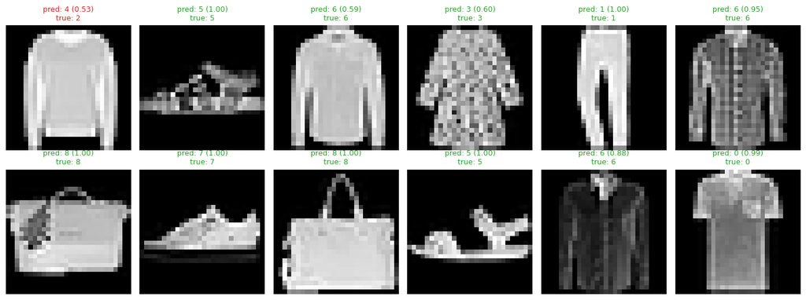

```
Predictions preprocessing: raw; unique predicted classes among first 14000 samples: 10
```

```python
# Image predictions visualization & confusion matrix (module calls)
import importlib, p2_nn_module as p2
importlib.reload(p2)

# Gallery of random predictions
_ = p2.visualize_test_images(
    X_test_img=X_test_f if 'X_test_f' in globals() else X_test,
    y_test_lbl=y_test_f if 'y_test_f' in globals() else y_test,
    model=globals().get('model_fashion'),
    label_encoder=globals().get('le'),
    x_scaler=globals().get('x_scaler'),
    k=12,
    cols=6,
    random_seed=42,
)
```

Now we explore the confusion matrix for this classifier to explain what classes are the most challenging.

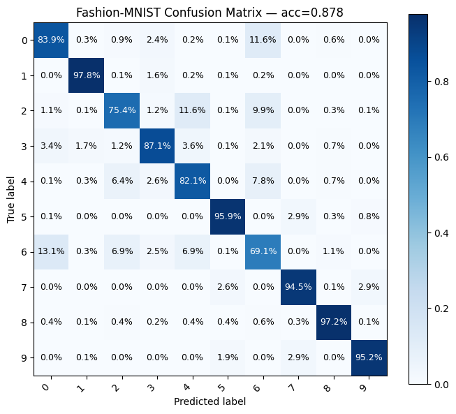

```
{'confusion_accuracy': 0.8782857142857143}
```

```python
# Confusion matrix
cm_res = p2.confusion_matrix_plot(
    model=globals().get('model_fashion'),
    X=X_test_f if 'X_test_f' in globals() else X_test,
    y_true=Y_test_f if 'Y_test_f' in globals() else y_test,
    label_encoder=globals().get('le'),
    title='Fashion-MNIST Confusion Matrix',
)
print({'confusion_accuracy': cm_res['accuracy']})
```

## How we measure accuracy here

We report overall classification accuracy computed from the confusion matrix. Let $\mathrm{CM}$ be the (unnormalized) confusion matrix, where $\mathrm{CM}_{ij}$ counts how many samples of true class $i$ were predicted as class $j$. The diagonal entries $\mathrm{CM}_{ii}$ are correct predictions.

- Overall accuracy is the fraction of correct predictions among all samples:

$$ \text{Accuracy} = \frac{\sum_{i=1}^{K} \mathrm{CM}_{ii}}{\sum_{i=1}^{K}\sum_{j=1}^{K} \mathrm{CM}_{ij}} = \frac{\mathrm{trace}(\mathrm{CM})}{\sum \mathrm{CM}}. $$

- In code, this equals `sklearn.metrics.accuracy_score(y_true, y_pred)` and also matches `np.trace(CM) / CM.sum()` when `CM` is the raw count matrix.

Notes on normalization and display:

- We often display a normalized confusion matrix for readability (e.g., each row sums to 1). Normalization affects only the displayed cell values, not how accuracy is computed.
- The accuracy number is always computed from the raw counts before normalization.

### Results

Our model acheived 'test_acc': 0.87. This shows that our FFNN can generalize to more complex datasets. It would be beneficial to explore larger / deeper model architectures to select the best fit for this more complex dataset.

### Part g) Critical evaluation of the various algorithms

After all these glorious calculations, you should now summarize the various algorithms and come with a critical evaluation of their pros and cons. Which algorithm works best for the regression case and which is best for the classification case. These codes can also be part of your final project 3, but now applied to other data sets.

## Summary of methods to implement and analyze

**Required Implementation:**

1. Reuse the regression code and results from project 1, these will act as a benchmark for seeing how suited a neural network is for this regression task.
2. Implement a neural network with
- A flexible number of layers
- A flexible number of nodes in each layer
- A changeable activation function in each layer (Sigmoid, ReLU, LeakyReLU, as well as Linear and Softmax)
- A changeable cost function, which will be set to MSE for regression and cross-entropy for multiple-classification
- An optional L1 or L2 norm of the weights and biases in the cost function (only used for computing gradients, not interpretable metrics)
3. Implement the back-propagation algorithm to compute the gradient of your neural network
4. Reuse the implementation of Plain and Stochastic Gradient Descent from Project 1 (and adapt the code to work with the your neural network)
- With no optimization algorithm
- With RMS Prop
- With ADAM
5. Implement scaling and train-test splitting of your data, preferably using sklearn
6. Implement and compute metrics like the MSE and Accuracy

### Required Analysis:

1. Briefly show and argue for the advantages and disadvantages of the methods from Project 1.
2. Explore and show the impact of changing the number of layers, nodes per layer, choice of activation function, and inclusion of L1 and L2 norms. Present only the most interesting results from this exploration. 2D Heatmaps will be good for this: Start with finding a well performing set of hyper-parameters, then change two at a time in a range that shows good and bad performance.
3. Show and argue for the advantages and disadvantages of using a neural network for regression on your data
4. Show and argue for the advantages and disadvantages of using a neural network for classification on your data
5. Show and argue for the advantages and disadvantages of the different gradient methods and learning rates when training the neural network

### Optional (Note that you should include at least two of these in the report):

1. Implement Logistic Regression as simple classification model case (equivalent to a Neural Network with just the output layer)
2. Compute the gradient of the neural network with autograd, to show that it gives the same result as your hand-written backpropagation.
3. Compare your results with results from using a machine-learning library like pytorch (https://docs.pytorch.org/tutorials/beginner/basics/buildmodel_tutorial.html)
4. Use a more complex classification dataset instead, like the fashion MNIST (see https://www.kaggle.com/datasets/zalando-research/fashionmnist)
5. Use a more complex regression dataset instead, like the two-dimensional Runge function $f(x,y)=\left[(10x - 5)^2 + (10y - 5)^2 + 1 \right]^{-1}$, or even more complicated two-dimensional functions (see the supplementary material of https://www.nature.com/articles/s41467-025-61362-4 for an extensive list of two-dimensional functions).
6. Compute and interpret a confusion matrix of your best classification model (see https://www.researchgate.net/figure/Confusion-matrix-of-MNIST-and-F-MNIST-embeddings_fig5_349758607)

## Background literature

1. The text of Michael Nielsen is highly recommended, see Nielsen's book at http://neuralnetworksanddeeplearning.com/. It is an excellent read.
2. Goodfellow, Bengio and Courville, Deep Learning at https://www.deeplearningbook.org/. Here we recommend chapters 6, 7 and 8
3. Raschka et al. at https://sebastianraschka.com/blog/2022/ml-pytorch-book.html. Here we recommend chapters 11, 12 and 13.

## Introduction to numerical projects

Here follows a brief recipe and recommendation on how to write a report for each project.

- Give a short description of the nature of the problem and the eventual numerical methods you have used.
- Describe the algorithm you have used and/or developed. Here you may find it convenient to use pseudocoding. In many cases you can describe the algorithm in the program itself.
- Include the source code of your program. Comment your program properly.
- If possible, try to find analytic solutions, or known limits in order to test your program when developing the code.
- Include your results either in figure form or in a table. Remember to label your results. All tables and figures should have relevant captions and labels on the axes.
- Try to evaluate the reliabilty and numerical stability/precision of your results. If possible, include a qualitative and/or quantitative discussion of the numerical stability, eventual loss of precision etc.
- Try to give an interpretation of you results in your answers to the problems.
- Critique: if possible include your comments and reflections about the exercise, whether you felt you learnt something, ideas for improvements and other thoughts you've made when solving the exercise. We wish to keep this course at the interactive level and your comments can help us improve it.
- Try to establish a practice where you log your work at the computerlab. You may find such a logbook very handy at later stages in your work, especially when you don't properly remember what a previous test version of your program did. Here you could also record the time spent on solving the exercise, various algorithms you may have tested or other topics which you feel worthy of mentioning.

## Format for electronic delivery of report and programs

The preferred format for the report is a PDF file. You can also use DOC or postscript formats or as an ipython notebook file. As programming language we prefer that you choose between C/C++, Fortran2008 or Python. The following prescription should be followed when preparing the report:

- Use Canvas to hand in your projects, log in at https://www.uio.no/english/services/it/education/canvas/ with your normal UiO username and password.
- Upload **only** the report file or the link to your GitHub/GitLab or similar typo of repos! For the source code file(s) you have developed please provide us with your link to your GitHub/GitLab or similar domain. The report file should include all of your discussions and a list of the codes you have developed. Do not include library files which are available at the course homepage, unless you have made specific changes to them.
- In your GitHub/GitLab or similar repository, please include a folder which contains selected results. These can be in the form of output from your code for a selected set of runs and input parameters.

Finally, we encourage you to collaborate. Optimal working groups consist of 2-3 students. You can then hand in a common report.